# Product Analytics Camp - Test Task

## Problem:

You're a marketing analyst and you've been told by the Senior Marketing Manager that recent marketing campaigns have not been as effective as they were expected to be. You need to analyze the data set in order to understand this problem and propose data-driven solutions. You are required to solve the following questions to generate a report for your management.

## Task:

Provide Exploratory Data Analysis (EDA Analysis) for the data set

## 1. Import related modules

```python
import numpy as np
import pandas as pd
import datetime as dt
import matplotlib.pyplot as plt
import seaborn as sns
```

## 2. Import and clean the dataset.

```python
marketing_data = pd.read_csv('csv/marketing_data.csv')
```

#### Define a function to help to explore data

```python
def basic_information(df):
    print('----------------The first 5 rows of data----------------')
    print(df.head())
    print('----------------Brief summary----------------')
    print(df.info())
    print('----------------Data set size----------------')
    print(df.shape)
    print('----------------Column name----------------')
    print(df.columns)
    print('----------------Numerical features----------------')
    print(df.describe())
    print('----------------Unique data----------------')
    for i in df.columns:
        print(F'{i}:',len(df[i].unique()))
```

```python
basic_information(marketing_data)
```

```
----------------The first 5 rows of data----------------
      ID  Year_Birth   Education Marital_Status      Income   Kidhome  \
0   1826        1970  Graduation       Divorced  $84,835.00         0
1      1        1961  Graduation         Single  $57,091.00         0
2  10476        1958  Graduation        Married  $67,267.00         0
3   1386        1967  Graduation       Together  $32,474.00         1
4   5371        1989  Graduation         Single  $21,474.00         1

   Teenhome Dt_Customer  Recency  MntWines  ...  NumStorePurchases  \
0         0     6/16/14        0       189  ...                  6
1         0     6/15/14        0       464  ...                  7
2         1     5/13/14        0       134  ...                  5
3         1     5/11/14        0        10  ...                  2
4         0      4/8/14        0         6  ...                  2

   NumWebVisitsMonth  AcceptedCmp3  AcceptedCmp4  AcceptedCmp5  AcceptedCmp1  \
0                  1             0             0             0             0
1                  5             0             0             0             0
2                  2             0             0             0             0
3                  7             0             0             0             0
4                  7             1             0             0             0

   AcceptedCmp2  Response  Complain  Country
0             0         1         0       SP
1             1         1         0       CA
2             0         0         0       US
3             0         0         0      AUS
4             0         1         0       SP

[5 rows x 28 columns]
----------------Brief summary----------------
<class 'pandas.core.frame.DataFrame'>
RangeIndex: 2240 entries, 0 to 2239
Data columns (total 28 columns):
 #   Column               Non-Null Count  Dtype
---  ------               --------------  -----
 0   ID                   2240 non-null   int64
 1   Year_Birth           2240 non-null   int64
 2   Education            2240 non-null   object
 3   Marital_Status       2240 non-null   object
```

[output cut: 104 more lines]

```
MntSweetProducts: 177
MntGoldProds: 213
NumDealsPurchases: 15
NumWebPurchases: 15
NumCatalogPurchases: 14
NumStorePurchases: 14
NumWebVisitsMonth: 16
AcceptedCmp3: 2
AcceptedCmp4: 2
AcceptedCmp5: 2
AcceptedCmp1: 2
AcceptedCmp2: 2
Response: 2
Complain: 2
Country: 8
```

#### Clean the data

```python
# Income column has object Dtype
marketing_data.rename({' Income ' : 'Income'}, axis = 1, inplace = True)
marketing_data['Income'] = marketing_data['Income'].str.replace('$', '', regex=True)
marketing_data['Income'] = marketing_data['Income'].str.replace(',', '', regex=True).astype(float)
# Dt_Customer column has object Dtype
marketing_data['Dt_Customer'] = pd.to_datetime(marketing_data['Dt_Customer'])
```

Year_Birth has 1893 minimun value. It seems like a mistake. Let analyse the data scatter

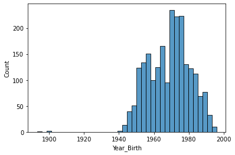

```python
sns.histplot(data=marketing_data, x="Year_Birth")
```

```python
# We need to delete unrealistic long-livers from our dataset
marketing_data = marketing_data.loc[(marketing_data['Year_Birth'] > 1920)]
```

## 3. EDA Analysis of the dataset

```python
%%HTML
<div class='tableauPlaceholder' id='viz1645114616576' style='position: relative'><object class='tableauViz'  style='display:none;'><param name='host_url' value='https%3A%2F%2Fpublic.tableau.com%2F' /> <param name='embed_code_version' value='3' /> <param name='site_root' value='' /><param name='name' value='United_Camp&#47;Dashboard3' /><param name='tabs' value='no' /><param name='toolbar' value='yes' /><param name='animate_transition' value='yes' /><param name='display_static_image' value='yes' /><param name='display_spinner' value='yes' /><param name='display_overlay' value='yes' /><param name='display_count' value='yes' /><param name='language' value='en-US' /><param name='filter' value='publish=yes' /></object></div>                <script type='text/javascript'>                    var divElement = document.getElementById('viz1645114616576');                    var vizElement = divElement.getElementsByTagName('object')[0];                    if ( divElement.offsetWidth > 800 ) { vizElement.style.width='100%';vizElement.style.height=(divElement.offsetWidth*0.75)+'px';} else if ( divElement.offsetWidth > 500 ) { vizElement.style.width='100%';vizElement.style.height=(divElement.offsetWidth*0.75)+'px';} else { vizElement.style.width='100%';vizElement.style.height='1977px';}                     var scriptElement = document.createElement('script');                    scriptElement.src = 'https://public.tableau.com/javascripts/api/viz_v1.js';                    vizElement.parentNode.insertBefore(scriptElement, vizElement);                </script>
```

[figure not shown]

To understand what is wrong with recent marketing campaigns we need to visualize campaign dynamics

```python
%%HTML
<div class='tableauPlaceholder' id='viz1645262823873' style='position: relative'><object class='tableauViz'  style='display:none;'><param name='host_url' value='https%3A%2F%2Fpublic.tableau.com%2F' /> <param name='embed_code_version' value='3' /> <param name='site_root' value='' /><param name='name' value='United_Camp_cam_dynamics&#47;Dashboard2' /><param name='tabs' value='no' /><param name='toolbar' value='yes' /><param name='animate_transition' value='yes' /><param name='display_static_image' value='yes' /><param name='display_spinner' value='yes' /><param name='display_overlay' value='yes' /><param name='display_count' value='yes' /><param name='language' value='en-US' /><param name='filter' value='publish=yes' /></object></div>                <script type='text/javascript'>                    var divElement = document.getElementById('viz1645262823873');                    var vizElement = divElement.getElementsByTagName('object')[0];                    if ( divElement.offsetWidth > 800 ) { vizElement.style.width='100%';vizElement.style.height=(divElement.offsetWidth*0.75)+'px';} else if ( divElement.offsetWidth > 500 ) { vizElement.style.width='100%';vizElement.style.height=(divElement.offsetWidth*0.75)+'px';} else { vizElement.style.width='100%';vizElement.style.height='1127px';}                     var scriptElement = document.createElement('script');                    scriptElement.src = 'https://public.tableau.com/javascripts/api/viz_v1.js';                    vizElement.parentNode.insertBefore(scriptElement, vizElement);                </script>
```

[figure not shown]

#### Conclusions

1. Overall dynamics of all marketing campaigns fall
2. Montenegro is the only country with almost zero response to marketing campaigns
3. We have a big fall in response to the last campaign through analized period
4. Comparing 14Q1 and 14Q2 we have problems with campaigns #4, #5 and last campaign

Lets compare Q1 and Q2 in more detales

```python
%%HTML
<div class='tableauPlaceholder' id='viz1645262959435' style='position: relative'><object class='tableauViz'  style='display:none;'><param name='host_url' value='https%3A%2F%2Fpublic.tableau.com%2F' /> <param name='embed_code_version' value='3' /> <param name='site_root' value='' /><param name='name' value='United_Camp_cam_dynamics&#47;Dashboard1' /><param name='tabs' value='no' /><param name='toolbar' value='yes' /><param name='animate_transition' value='yes' /><param name='display_static_image' value='yes' /><param name='display_spinner' value='yes' /><param name='display_overlay' value='yes' /><param name='display_count' value='yes' /><param name='language' value='en-US' /><param name='filter' value='publish=yes' /></object></div>                <script type='text/javascript'>                    var divElement = document.getElementById('viz1645262959435');                    var vizElement = divElement.getElementsByTagName('object')[0];                    if ( divElement.offsetWidth > 800 ) { vizElement.style.width='100%';vizElement.style.height=(divElement.offsetWidth*0.75)+'px';} else if ( divElement.offsetWidth > 500 ) { vizElement.style.width='100%';vizElement.style.height=(divElement.offsetWidth*0.75)+'px';} else { vizElement.style.width='100%';vizElement.style.height='827px';}                     var scriptElement = document.createElement('script');                    scriptElement.src = 'https://public.tableau.com/javascripts/api/viz_v1.js';                    vizElement.parentNode.insertBefore(scriptElement, vizElement);                </script>
```

[figure not shown]

#### Conclusions

1. We have drop in response to marketing campaigns in Canada, Germany, and India. Spain hasn’t any drops in sales channels
2. In Canada, we need to fix Web and Store marketing, Germany – Catalog, India – all sales channels.
3. In Canada, Germany, India, and Spain we need to focus on Wines and Meat sales because of the huge drop in sales in these categories